# Effect of Group Projects on Willingness to Take a College Class at Boston University

## Covariates to Improve Precision

To see if we could improve the precision of our understanding of student signups, we decided to add pre-treatment covariates to our regression model. We chose to add variables which had no issues with the randomization check as well. So, we tested whether or not a student had taken a class in that department previously, their transfer student status, their international student status. In an effort to avoid p-hacking, we did not include the school variable or class year here because that would add seven more predictors, one per school less one excluded school, to our regression. Under the same rationale, we kept the class years out of this analysis as well.

[output not shown]

## Heterogeneity Among Class Years

We also thought it would be relevant to explore our data for heterogeneous treatment effects. The first analysis we wanted to test for heterogeneous treatment effects was testing by class year with the intuition that being in different years of college could lead to a different approach to selecting classes.

|  | Freshmen | Sophomores | Juniors | Seniors |
| --- | --- | --- | --- | --- |
| (Intercept) | 0.491*** | 0.494*** | 0.458*** | 0.556*** |
|  | (0.038) | (0.039) | (0.040) | (0.055) |
| TREATED | 0.055 | 0.062 | 0.096+ | -0.073 |
|  | (0.053) | (0.054) | (0.057) | (0.077) |
| TREATED × FRESHMAN | -0.055 |  |  |  |
|  | (0.176) |  |  |  |
| TREATED × SOPHOMORE |  | -0.100 |  |  |
|  |  | (0.154) |  |  |
| TREATED × JUNIOR |  |  | -0.221+ |  |
|  |  |  | (0.122) |  |
| TREATED × SENIOR |  |  |  | 0.213* |
|  |  |  |  | (0.102) |
| Num.Obs. | 396 | 396 | 396 | 396 |

+ p < 0.1, * p < 0.05, ** p < 0.01, *** p < 0.001

While not all of the values above were statistically significant, we wanted to visualize sign up by class year to get an imprecise estimate of the conditional average treatment effect.

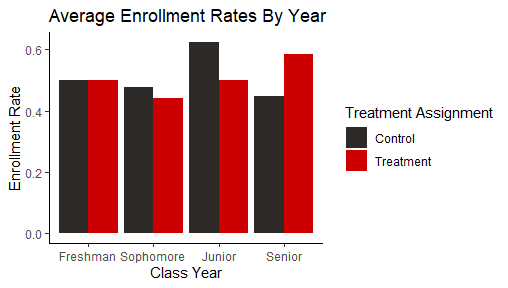

## Heterogeneity Among Different Classes

One other avenue that we wanted to explore for heterogeneity was exploring the behavior on a class-by-class basis. Our assertion here was that the treatment effect may differ depending on the class that is offering a group project over an exam.

[output not shown]

+ p < 0.1, * p < 0.05, ** p < 0.01, *** p < 0.001

Based on the table above, we can see that there are many classes with large interaction terms; you can find the full table of coefficients in appendix table 6. Despite the fact that they are not statistically significant, the point estimates of the interaction terms suggest that people have different attitudes toward group projects based on the class they’re looking at. For example, when a student gets treated and views a BA syllabus, they are more likely to sign up relative to those treated and looking at another syllabus. On the other hand, observe that people may be less likely to take a AR class if it has a group project relative to those who are looking at other syllabi with group projects. The large point estimates for each of these interaction terms, while not statistically significant at the 95% level, highlight the idea that some classes may be better off with final projects than others and warrants further research so that these trends can be backed with a higher level of confidence.

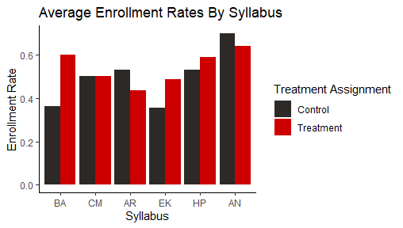

In the visualization above, we can observe the gap between treatment assignments as an imprecise reflection of the conditional ATE for each of our class syllabi. Like the first chart, not all coefficients that comprise this CATE estimate are not statistically significant. However, a key observation of appendix table 6 is that the coefficients for certain classes, AN, are statistically significant at the 95% level. This means that we can be confident that the anthropology class has a much higher enrollment rate than other classes independent of the treatment and this is clearly reflected in the chart. Like we saw from the interaction terms, it appears that there is a large point estimate difference in willingness to sign up for the BA class between group project and final exam, but we cannot confirm this at the 95% percent confidence level (Appendix Table 6). Overall, this chart illustrates the range of outcomes for each of the classes we tested and an imprecise estimate of how the treatment affects enrollment in each class.

## Fixed Effects

In an effort to account for the differences of each person, both those we asked questions about and those we did not consider, we elected to run a regression on our treatment using a fixed effect at the individual level. The output below shows us that when we account for the differences between people using fixed effects, we see an average treatment estimate of 10.5 percentage points, which is larger than our original regression estimate.

|  | Survey ID Fixed Effect |
| --- | --- |
| TREATED | 0.105+ |
|  | (0.058) |
| Num.Obs. | 396 |
| FE: SURVEYID | X |

+ p < 0.1, * p < 0.05, ** p < 0.01, *** p < 0.001

# Limitations

One other limitation of our experimental design is that it did not account for all previous classes one has taken nor their majors. We did notice that taking a class previously increases enrollment, but without this data we cannot fully understand why. Moreover, asking about previous classes does not indicate how a student’s emotional experiences with a related class shapes their expectation of another. These factors could have been vital to a student’s decision to enroll in a class, but they are factors that are difficult to properly measure and analyze. One final limitation of our analysis was that we asked first-semester freshmen for GPA when they don’t have one. While we could have pursued a workaround involving dummy variables for missing GPAs, we elected not to do so and thus we could not explore the relationship between GPA, the treatment, and enrollment. By understanding and responding to these limitations, further research on the topic can be more conclusive and generalizable.

# Conclusion

By exposing students to different versions of syllabi with exams or group projects as the final assessments, we were able to identify several opportunities for future work. We did not find a statistically significant average treatment effect between the control and treatment syllabi, thus we cannot reject the null hypothesis that introducing a group project will affect student enrollment. We utilized person-level fixed effects to account for the differences between students and got a larger point estimate, but this result was not significant either.

While we could not identify a statistically significant average treatment effect with or without fixed effects, we found a statistically significant interaction term between being a senior and receiving the treatment. This presents suggestive evidence that when someone is a senior, they may be more willing to take classes with final group projects relative to people of other class years. With 95% confidence, we also found that anthropology courses have a higher base enrollment rate relative to other classes tested and that taking at least one class in a department has a positive effect on enrolling in another class from that department; however, these observations were unrelated to our treatment. We did not find statistically significant interaction terms or treatment effects for heterogeneity across the different classes we presented syllabi for. However, this was another case where we saw large point estimates and different effects by class that deserve a follow up experiment with higher statistical power.

Between the analysis and limitations, this work lays the foundation for future research in higher education curriculum design and presents frameworks to analyze students’ characteristics and departmental differences to optimize enrollment.

# Bibliography

Bloom, Davida. “Collaborative Test Taking: Benefits for Learning and Retention.” College Teaching, vol. 57, no. 4, 2009, pp. 216–220.

Pedro Arce. “Group Projects Based Final Exams.” Association for Engineering Education - Engineering Library Division Papers, 1999, p. 4.281.1.

# Appendix

## Sign Up Form (Appendix Exhibit 1)

## Reminder Email (Appendix Exhibit 2)

## Sample of Treatment Syllabus (Appendix Exhibit 3)

## Sample of Control Syllabus (Appendix Exhibit 4)

## Extra Randomization Check for Class Year (Table 1)

## Extra Randomization Check for Other Covariates (Table 2)

## Extra Randomization Check for School (Table 3)

## Extra Randomization Checks for Survey Assigment (Table 4)

## Power of our Experiment (Output 1)

## Required Student-Syllabus Pairs for an Experiment with 80% Power (Output 2)

## Full table showing heterogeneity between class years (Table 5)

## Full table showing heterogeneity between classes (Table 6)

|  | BA | CM | AR | EK | HP | AN |
| --- | --- | --- | --- | --- | --- | --- |
| (Intercept) | 0.522*** | 0.491*** | 0.484*** | 0.519*** | 0.484*** | 0.454*** |
|  | (0.040) | (0.039) | (0.040) | (0.039) | (0.040) | (0.039) |
| TREATED | 0.009 | 0.060 | 0.077 | 0.035 | 0.048 | 0.067 |
|  | (0.055) | (0.055) | (0.055) | (0.055) | (0.055) | (0.055) |
| SURVEY_1 | -0.161+ |  |  |  |  |  |
|  | (0.090) |  |  |  |  |  |
| TREATED × SURVEY_1 | 0.229+ |  |  |  |  |  |
|  | (0.133) |  |  |  |  |  |
| SURVEY_2 |  | 0.009 |  |  |  |  |
|  |  | (0.100) |  |  |  |  |
| TREATED × SURVEY_2 |  | -0.060 |  |  |  |  |
|  |  | (0.136) |  |  |  |  |
| SURVEY_3 |  |  | 0.045 |  |  |  |
|  |  |  | (0.095) |  |  |  |
| TREATED × SURVEY_3 |  |  | -0.169 |  |  |  |
|  |  |  | (0.135) |  |  |  |
| SURVEY_4 |  |  |  | -0.164+ |  |  |
|  |  |  |  | (0.095) |  |  |
| TREATED × SURVEY_4 |  |  |  | 0.096 |  |  |
|  |  |  |  | (0.133) |  |  |
| SURVEY_5 |  |  |  |  | 0.047 |  |
|  |  |  |  |  | (0.097) |  |
| TREATED × SURVEY_5 |  |  |  |  | 0.009 |  |
|  |  |  |  |  | (0.135) |  |
| SURVEY_6 |  |  |  |  |  | 0.246** |
|  |  |  |  |  |  | (0.093) |
| TREATED × SURVEY_6 |  |  |  |  |  | -0.128 |
|  |  |  |  |  |  | (0.129) |
| Num.Obs. | 396 | 396 | 396 | 396 | 396 | 396 |
| R2 | 0.011 | 0.003 | 0.007 | 0.011 | 0.004 | 0.022 |
| R2 Adj. | 0.004 | -0.004 | 0.000 | 0.003 | -0.004 | 0.015 |
| R2 Within |  |  |  |  |  |  |
| R2 Pseudo |  |  |  |  |  |  |
| AIC | 577.8 | 581.0 | 579.5 | 578.0 | 580.8 | 573.5 |
| BIC | 593.7 | 597.0 | 595.4 | 593.9 | 596.7 | 589.4 |
| Log.Lik. | -284.903 | -286.518 | -285.729 | -285.003 | -286.383 | -282.733 |

+ p < 0.1, * p < 0.05, ** p < 0.01, *** p < 0.001